# data.replication.rmd

Karim Primov

3/15/2022

Title: Remote reefs and seamounts are the last refuges for marine predators across the Indo-Pacific

Link to the paper: https://journals.plos.org/plosbiology/article?id=10.1371/journal.pbio.3000366#pbio.3000366.s007

Introduction: With technological advancements taking place in the fisheries industry, there has been unprecedented access to populations of marine predators including sharks, tuna, and billfishes, among others. In order to protect and preserve populations of marine predators, it is necessary to identify critical habitats of these marine predators across shallow coral reefs and in the deep ocean. 1041 mid-water baited videos were used to survey sharks and other pelagic predators across the Indo-Pacific. Three predator community attributes were modeled as a function of either geomorphology, environmental conditions, and human pressures: species richness, mean maximum body size, and shark abundance.

Data Used: The primary data used for statistical and visual analyses in this study was raw vertebrate species richness, body size, shark abundance, and a wide variety of environmental, geomorphological, and human pressure predator community attributes at 1041 individual baited video deployments spread between the Eastern Indian and Western Pacific Oceans.

Analyses Conducted in paper: In this study, frequency distributions of species richness, body size, and shark abundance are plotted across all deployments, and shark abundances are plotted for each region in which baited remote underwater video systems were deployed. In addition, boosted regression trees are plotted to identify the relative contribution of variables contained within the three classes of predator community attributes to species richness, body size, and shark abundance across all 1041 deployments. In addition, species richness was assessed based on both distance to coast and distance to the Coral Triangle, body size was assessed based on both depth as well as distance to the nearest market, and shark abundance was assessed based on both distance to the nearest market and depth. Finally, the frequency distributions of predator attributes, specifically species richness, body size, and shark abundance, were plotted with respect to three different spatial management regimes: unprotected, partially protected, and large, no-take marine protected areas.

Conclusions: All three attributes (species richness, mean maximum body size, and shark abundance) were primarily driven by geomorphology and environmental conditions, while human pressures, specifically distance to human markets, influenced body size and shark abundance, but not species richness. Refuges were identified > 1250 km from human markets and were identified as remote and shallow seabeds (e.g. seamounts, submerged banks, and reefs). Many of the refuges for both large-bodied predators and hotspots of shark abundance are currently under-represented within no-take marine protected areas (MPAs), and population recovery is unlikely to occur without strategic implementation of large, no-take MPAs that include these remote refuges as well as coastal areas.

Loading libraries

```r
library(readr)
library(gbm)
library(tidyverse)
```

```r
library(ggplot2)
library(ggridges)
library(tm)
library(expm)
library(e1071)
library(pdp)
library(knitr)
library(dplyr)
library(janitor)
library(readr)
```

Function gbm.plot from the gbm package in R to be used in boosted regression tree analysis

```r
gbm.plot <-
  function(gbm.object,                # a gbm object - could be one from gbm.step
           variable.no = 0,               # the var to plot - if zero then plots all
           nt = gbm.object$n.trees,       # how many trees to use
           smooth = FALSE,                # should we add a smoothed version of the fitted function
           rug = T,                       # plot a rug of deciles
           n.plots = length(pred.names),  # plot the first n most important preds
           common.scale = T,              # use a common scale on the y axis
           write.title = T,               # plot a title above the plot
           y.label = "fitted function",   # the default y-axis label
           x.label = NULL,                # the default x-axis label
           show.contrib = T,              # show the contribution on the x axis
           plot.layout = c(3,4),          # define the default layout for graphs on the page
           rug.side = 3,                  # which axis for rug plot? default (3) is top; bottom=1
           rug.lwd = 1,                   # line width for rug plots
           rug.tick = 0.03,               # tick length for rug plots
           ...                            # other arguments to pass to the plotting
           # useful options include cex.axis, cex.lab, etc.
  )
  {
    # function to plot gbm response variables, with the option
    # of adding a smooth representation of the response if requested
    # additional options in this version allow for plotting on a common scale
    # note too that fitted functions are now centered by subtracting their mean
    #
    # version 2.9
    #
    # j. leathwick/j. elith - March 2007
    #

    require(gbm)
    require(splines)

    gbm.call <- gbm.object$gbm.call
    gbm.x <- gbm.call$gbm.x
    pred.names <- gbm.call$predictor.names
    response.name <- gbm.call$response.name
    dataframe.name <- gbm.call$dataframe
    data <- eval(parse(text = dataframe.name))

    max.plots <- plot.layout[1] * plot.layout[2]
    plot.count <- 0
    n.pages <- 1

    if (length(variable.no) > 1) {stop("only one response variable can be plotted at a time")}

    if (variable.no > 0) {   #we are plotting all vars in rank order of contribution
      n.plots <- 1
    }

    max.vars <- length(gbm.object$contributions$var)
    if (n.plots > max.vars) {
      n.plots <- max.vars
      cat("warning - reducing no of plotted predictors to maximum available (",max.vars,")\n",sep="")
    }

    predictors <- list(rep(NA,n.plots)) # matrix(0,ncol=n.plots,nrow=100)
    responses <- list(rep(NA,n.plots)) # matrix(0,ncol=n.plots,nrow=100)

    for (j in c(1:n.plots)) {  #cycle through the first time and get the range of the functions
      if (n.plots == 1) {
        k <- variable.no
      }
      else k <- match(gbm.object$contributions$var[j],pred.names)

      if (is.null(x.label)) var.name <- gbm.call$predictor.names[k]
      else var.name <- x.label

      pred.data <- data[,gbm.call$gbm.x[k]]

      response.matrix <- plot.gbm(gbm.object, i.var = k, n.trees = nt, return.grid = TRUE,...)

      predictors[[j]] <- response.matrix[,1]
      if (is.factor(data[,gbm.call$gbm.x[k]])) {
        predictors[[j]] <- factor(predictors[[j]],levels = levels(data[,gbm.call$gbm.x[k]]))
      }
      responses[[j]] <- response.matrix[,2] - mean(response.matrix[,2])

      if(j == 1) {
        ymin = min(responses[[j]])
        ymax = max(responses[[j]])
      }
      else {
        ymin = min(ymin,min(responses[[j]]))
        ymax = max(ymax,max(responses[[j]]))
      }
    }

    # now do the actual plots

    for (j in c(1:n.plots)) {

      if (plot.count == max.plots) {
        plot.count = 0
        n.pages <- n.pages + 1
      }

      if (plot.count == 0) {
        windows(width = 11, height = 8)
        par(mfrow = plot.layout)
      }

      plot.count <- plot.count + 1

      if (n.plots == 1) {
        k <- match(pred.names[variable.no],gbm.object$contributions$var)
        if (show.contrib) {
          x.label <- paste(var.name,"  (",round(gbm.object$contributions[k,2],1),"%)",sep="")
        }
      }
      else {
        k <- match(gbm.object$contributions$var[j],pred.names)
        var.name <- gbm.call$predictor.names[k]
        if (show.contrib) {
          x.label <- paste(var.name,"  (",round(gbm.object$contributions[j,2],1),"%)",sep="")
        }
        else x.label <- var.name
      }

      if (common.scale) {
        plot(predictors[[j]],responses[[j]],ylim=c(ymin,ymax), type='l',
             xlab = x.label, ylab = y.label, ...)
      }
      else {
        plot(predictors[[j]],responses[[j]], type='l',
             xlab = x.label, ylab = y.label, ...)
      }
      if (smooth & is.vector(predictors[[j]])) {
        temp.lo <- loess(responses[[j]] ~ predictors[[j]], span = 0.3)
        lines(predictors[[j]],fitted(temp.lo), lty = 2, col = 2)
      }
      if (plot.count == 1) {
        if (write.title) {
          title(paste(response.name," - page ",n.pages,sep=""))
        }
        if (rug & is.vector(data[,gbm.call$gbm.x[k]])) {
          rug(quantile(data[,gbm.call$gbm.x[k]], probs = seq(0, 1, 0.1), na.rm = TRUE), side = rug.side, lwd = rug.lwd, ticksize = rug.tick)
        }
      }
      else {
        if (write.title & j == 1) {
          title(response.name)
        }
        if (rug & is.vector(data[,gbm.call$gbm.x[k]])) {
          rug(quantile(data[,gbm.call$gbm.x[k]], probs = seq(0, 1, 0.1), na.rm = TRUE), side = rug.side, lwd = rug.lwd, ticksize = rug.tick)
        }
      }
    }
  }
```

```r
library(readxl)
f <- read_excel("data/raw.sr.bodysize.sharkabundance.xlsx")
```

```
## * `` -> ...1
```

```r
colnames(f)[1] <- "location"
head(f)
```

```
## # A tibble: 6 × 21
##   location    SR TaSharks  MaxL Depth Chla_median Chla_sd SST_median SST_sd
##   <chr>    <dbl>    <dbl> <dbl> <dbl>       <dbl>   <dbl>      <dbl>  <dbl>
## 1 CH2001       2     3.25  45.1   328       0.127  0.0342       28.7  0.569
## 2 CH2003       4     3.36  41     377       0.137  0.0582       28.7  0.569
## 3 CH2004       4     3.31  52.9   494       0.137  0.0582       28.7  0.571
## 4 CH2005       3     3.31  44.6   494       0.137  0.0582       28.7  0.571
## 5 CH2006       3     3.3   46.9   494       0.137  0.0582       28.7  0.571
## 6 CH2007       5     3.36  55.5   494       0.137  0.0582       28.7  0.571
## # … with 12 more variables: pop_50km <dbl>, pop_500km <dbl>,
## #   Dist_nearest_pop <dbl>, Dist_nearest_market <dbl>, HDI <dbl>,
## #   Dcoast_km <dbl>, DCoralT_km <dbl>, DistSeamount_km <dbl>, GDP <dbl>,
## #   Dist_SMT1500 <dbl>, FishingEffort01 <dbl>, FishingEffort05 <dbl>
```

Line of code telling {knitr} where to find any images to include in “.html” output. These images are snapshots from the publication and will serve as comparisons to the results obtained from data re-analysis of the same figures.

```r
knitr::opts_chunk$set(fig.path = "images/")
```

First, plot species richness, mean maximum body size, and shark abundance across all locations:

Plotting frequency distributions of species richness, body size, and shark abundance: Note: Frequency distribution plots visualize the number of observations (in this case, values of species richness, body size, and shark abundance) within a certain range of values.

Species Richness (Figure 1B)

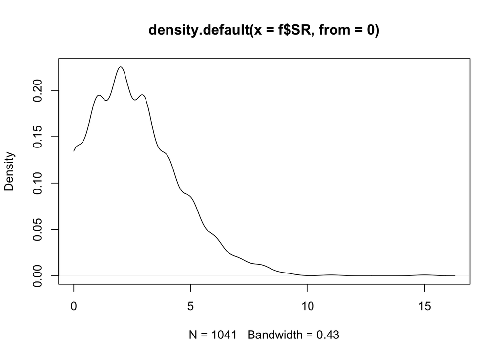

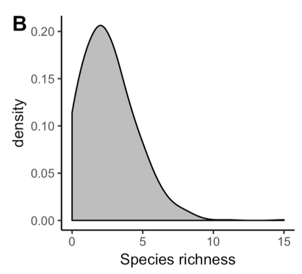

```r
#Species Richness
sr.density <- density(f$SR, from = 0)#obtaining frequency distribution of species richness using the density function
sr.density.plot <- plot(sr.density)#plotting the frequency distribution of species richness
```

Overall, the species richness graph in the paper and the one generated in re-analysis were fairly similar to one another with respect to scale on the x and y axis as well as distribution shape and position, however, the figure in the paper is more smoothly distributed, likely due to the number of bins or kernels used in plotting.

Body Size (Figure 1C)

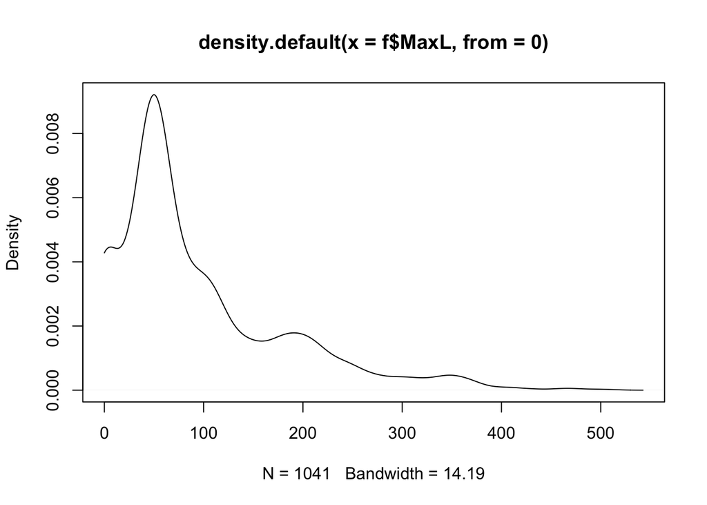

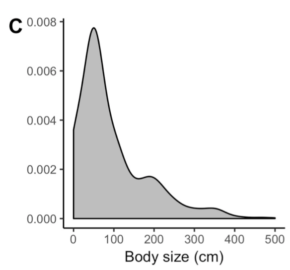

```r
#Body Size
body.size.density <- density(f$MaxL, from = 0)#obtaining frequency distribution of body size using the density function
body.size.density.plot <- plot(body.size.density)#plotting the frequency distribution of body size
```

Overall, the species richness graph in the paper and the one generated in re-analysis were fairly similar to one another with respect to scale on the x and y axis as well as distribution shape and position.

Shark Abundance (Figure 1D)

```r
#Shark Abundance

fb <- f %>% mutate(Shark.Abundance = exp(TaSharks)-1)#Shark abundance was recorded in raw data as TaSharks (log[SumMaxN +1]), so upon correspondence with the lead author, a new data frame was created called "fb" where a new column was mutated (created) called Shark.Abundance, which un-transformed (took the exponent of TaSharks and subtracted 1) TaSharks values at each deployment.
head(fb)
```

```
## # A tibble: 6 × 22
##   location    SR TaSharks  MaxL Depth Chla_median Chla_sd SST_median SST_sd
##   <chr>    <dbl>    <dbl> <dbl> <dbl>       <dbl>   <dbl>      <dbl>  <dbl>
## 1 CH2001       2     3.25  45.1   328       0.127  0.0342       28.7  0.569
## 2 CH2003       4     3.36  41     377       0.137  0.0582       28.7  0.569
## 3 CH2004       4     3.31  52.9   494       0.137  0.0582       28.7  0.571
## 4 CH2005       3     3.31  44.6   494       0.137  0.0582       28.7  0.571
## 5 CH2006       3     3.3   46.9   494       0.137  0.0582       28.7  0.571
## 6 CH2007       5     3.36  55.5   494       0.137  0.0582       28.7  0.571
## # … with 13 more variables: pop_50km <dbl>, pop_500km <dbl>,
## #   Dist_nearest_pop <dbl>, Dist_nearest_market <dbl>, HDI <dbl>,
## #   Dcoast_km <dbl>, DCoralT_km <dbl>, DistSeamount_km <dbl>, GDP <dbl>,
## #   Dist_SMT1500 <dbl>, FishingEffort01 <dbl>, FishingEffort05 <dbl>,
## #   Shark.Abundance <dbl>
```

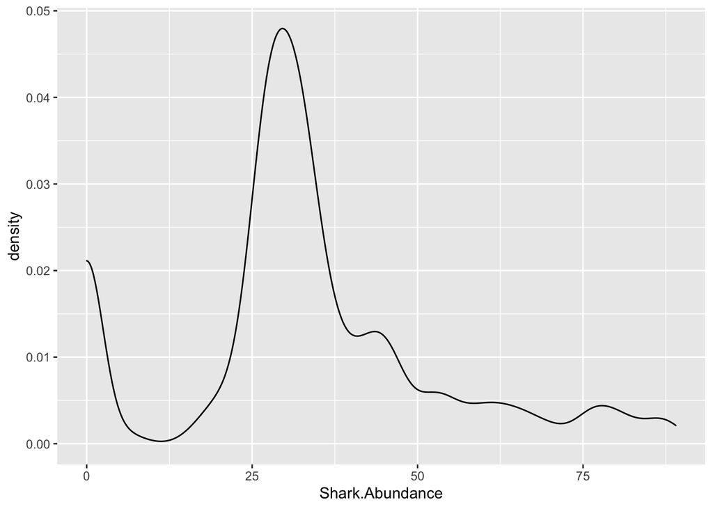

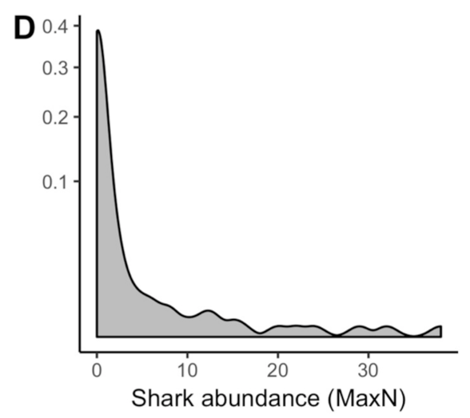

```r
a <- ggplot(fb, aes(x = Shark.Abundance))#plotting transformed shark abundance data using ggplot and taking frequency distribution using geom_density() function in ggplot2
a + geom_density()
```

Interestingly, the shark abundance plot generated in re-analysis of the transformed TaShark data is starkly different from the same shark abundance frequency distribution plot in the publication, both with respect to the shape of the plot as well as the scale of the plot. This may be either due to a faulty data transformation error in data re-analysis, or that TaSharks may be the wrong variable used to plot shark abundance.

Then, shark abundance was plotted for each region in which baited remote underwater video systems were deployed.

Shark Abundance Box plots (Figure 1E)

```r
fb$location <- gsub("[0-9]", "", as.character(f$location))#removing numbers from location column in dataframe "fb" for all 1041 deployments using function gsub to make sure all deployments from same geographic location had same name (e.g. CH2001 -> CH  & GAM051 -> GAM)
head(fb)
```

```
## # A tibble: 6 × 22
##   location    SR TaSharks  MaxL Depth Chla_median Chla_sd SST_median SST_sd
##   <chr>    <dbl>    <dbl> <dbl> <dbl>       <dbl>   <dbl>      <dbl>  <dbl>
## 1 CH           2     3.25  45.1   328       0.127  0.0342       28.7  0.569
## 2 CH           4     3.36  41     377       0.137  0.0582       28.7  0.569
## 3 CH           4     3.31  52.9   494       0.137  0.0582       28.7  0.571
## 4 CH           3     3.31  44.6   494       0.137  0.0582       28.7  0.571
## 5 CH           3     3.3   46.9   494       0.137  0.0582       28.7  0.571
## 6 CH           5     3.36  55.5   494       0.137  0.0582       28.7  0.571
## # … with 13 more variables: pop_50km <dbl>, pop_500km <dbl>,
## #   Dist_nearest_pop <dbl>, Dist_nearest_market <dbl>, HDI <dbl>,
## #   Dcoast_km <dbl>, DCoralT_km <dbl>, DistSeamount_km <dbl>, GDP <dbl>,
## #   Dist_SMT1500 <dbl>, FishingEffort01 <dbl>, FishingEffort05 <dbl>,
## #   Shark.Abundance <dbl>
```

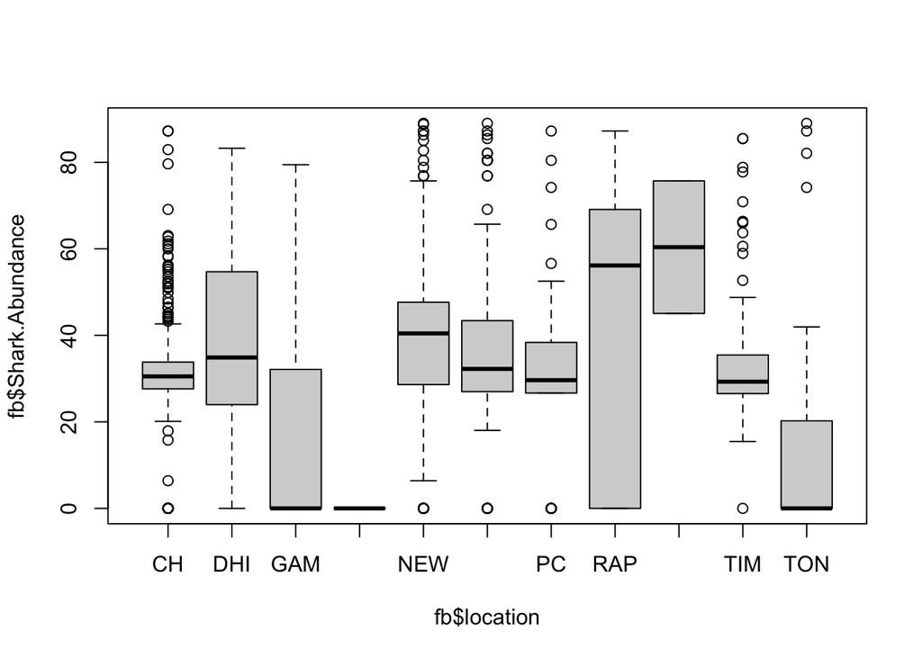

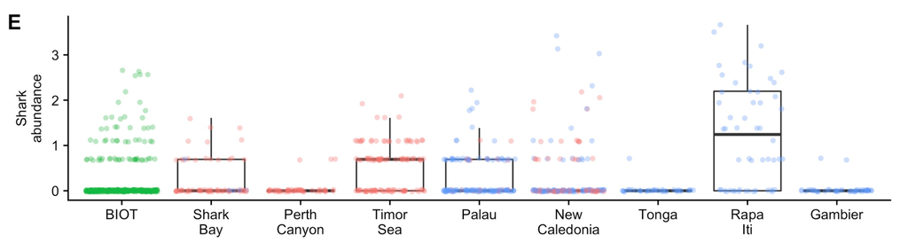

```r
shark.abund.boxplot <- boxplot(fb$Shark.Abundance~fb$location)#plotting shark abundance with respect to location (each region in which baited remote underwater video systems were deployed)
```

Similar to Figure 1D, Figure 1E in the re-analysis is starkly different than the Figure 1E plot in the publication. In the raw dataset (/data/raw.sr.bodysize.sharkabundance.xlsx), there are 1041 datapoints (individual deployments), the exact same number reported in the publication, however, there are 11 different locations listed in the raw data Excel sheet yet only 9 locations in the publication. Upon correspondence with the lead author, there were typos for the location name of some deployments, however, it was still difficult to assign mismatches to their proper locations since most locations had roughly, yet not the exact same number of deployments reported for both the publication and raw Excel sheet. Therefore, mismatches were left as such. Interestingly, despite the mismatches in number of deployments across sites, the scale of the plots (on the y-axis) are massively different and are much higher for the re-analyzed data, which are likely due to errors in data transformation or usage of the wrong variable (TaSharks) for plotting.

Note: Due to the difficulty of data transformation of shark abundance data, no further shark abundance analyses were performed in re-analysis.

Then, boosted regression trees (BRTs) were used to identify the relative contribution of multiple geomorphological, environmental, and human pressure variables to species richness and body size. Contribution of variables to shark abundance were not assessed. Parameters of model were included in file “brt.parameters.models.specific.predator.attributes.csv”.

```r
brt.parms <- read_csv("data/brt.parameters.models.specific.predator.attributes.csv")
brt.parms
```

```
## # A tibble: 11 × 4
##    `Model features`         `Vertebrate speci… `Weighted Body … `Shark abundanc…
##    <chr>                    <chr>              <chr>            <chr>
##  1 <NA>                     <NA>               <NA>             Log[SumMaxN +1]
##  2 Tree complexity          5                  5                5
##  3 Number of Trees          50                 50               50
##  4 Learning Rate            0.01               0.01             0.01
##  5 Bag Fraction             0.5                0.5              0.5
##  6 Family                   Poisson            Gaussian         Gaussian
##  7 Max Trees                1000               1000             1000
##  8 Spatial autocorrelation… 0.22               0.36             0.44
##  9 <NA>                     <NA>               <NA>             <NA>
## 10 Spatial autocorrelation… 0.023              0.24             -0.13
## 11 <NA>                     <NA>               <NA>             <NA>
```

Note: It was unclear how the authors went about narrowing down the number of community attributes used for the regression trees for species richness, body size, as well as shark abundance, or how they defined each variable as either a environmental, geomorphological, or human pressure predatory community attribute. Therefore, two BRTs were performed for species richness and body size each, one BRT with all potential explanatory variables that may contribute to the response variable, and one with just the variables included in the figure in the publication to see if the results found in the paper’s figures were obtainable.

Boosted Regression Trees (BRTs) for relative contribution of variables to Species Richness

Species Richness (Figure 3A) (includes all potential variables that may contribute to species richness across sites).

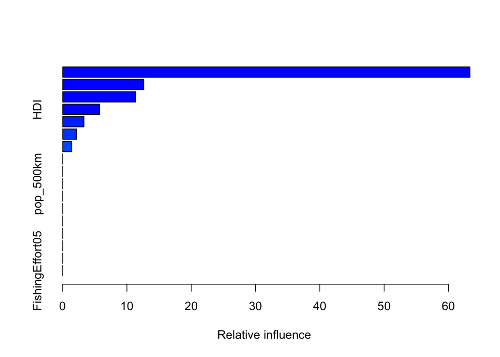

```
##                                     var   rel.inf
## SST_median                   SST_median 63.355604
## Chla_median                 Chla_median 12.615203
## SST_sd                           SST_sd 11.351448
## HDI                                 HDI  5.747944
## DCoralT_km                   DCoralT_km  3.317976
## Chla_sd                         Chla_sd  2.176220
## Dcoast_km                     Dcoast_km  1.435604
## Depth                             Depth  0.000000
## pop_50km                       pop_50km  0.000000
## pop_500km                     pop_500km  0.000000
## Dist_nearest_pop       Dist_nearest_pop  0.000000
## Dist_nearest_market Dist_nearest_market  0.000000
## DistSeamount_km         DistSeamount_km  0.000000
## GDP                                 GDP  0.000000
## Dist_SMT1500               Dist_SMT1500  0.000000
## FishingEffort01         FishingEffort01  0.000000
## FishingEffort05         FishingEffort05  0.000000
```

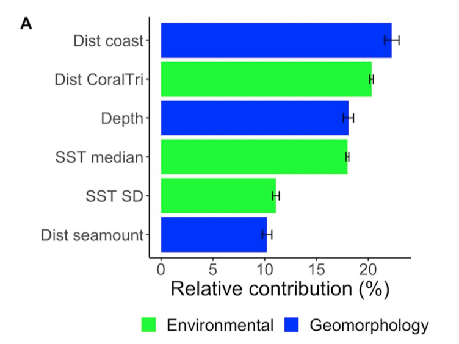

```r
#use species richness as the response variable, including all variables
boost.sp.rich.tree <- gbm(formula = SR~+Depth+Chla_median+Chla_sd+SST_median+SST_sd+pop_50km+pop_500km+Dist_nearest_pop+Dist_nearest_market+HDI+Dcoast_km+DCoralT_km+DistSeamount_km+GDP+Dist_SMT1500+FishingEffort01+FishingEffort05, data = fb, n.trees = 50, shrinkage = 0.01, bag.fraction = 0.5, distribution = "poisson")#using all  predator community attributes catergorized as either 1) geomorphology, 2) environmental conditions, or 3) human pressure to identify which had the highest relative influence on species richness using the gbm package and parameters specified in the file "brt.parameters.models.specific.predator.attributes.csv"
summary(boost.sp.rich.tree)  #summary of the results
```

The plot from Figure 3A in the publication is vastly different from the figure produced from re-analysis of the raw data. It was not clear if the authors had specific criteria for selecting contributing variables since only 6 variables were plotted as having influence on species richness, yet there were 17 variables from each of the 1041 deployments in the raw data set. It was also unclear whether any of the other variables underwent data transformation which I did not account for, which would likely influence these variable’s contribution to species richness. In addition, the file “brt.parameters.models.specific.predator.attributes.csv” included parameters included in Figure 3A in the paper, however, I was unable to add spatial autocorrelation as a parameter in the model, which likely also influenced the outcome of the re-analyzed BRT.

Species Richness (using variables found as having highest relative contribution in Figure3A in publication)

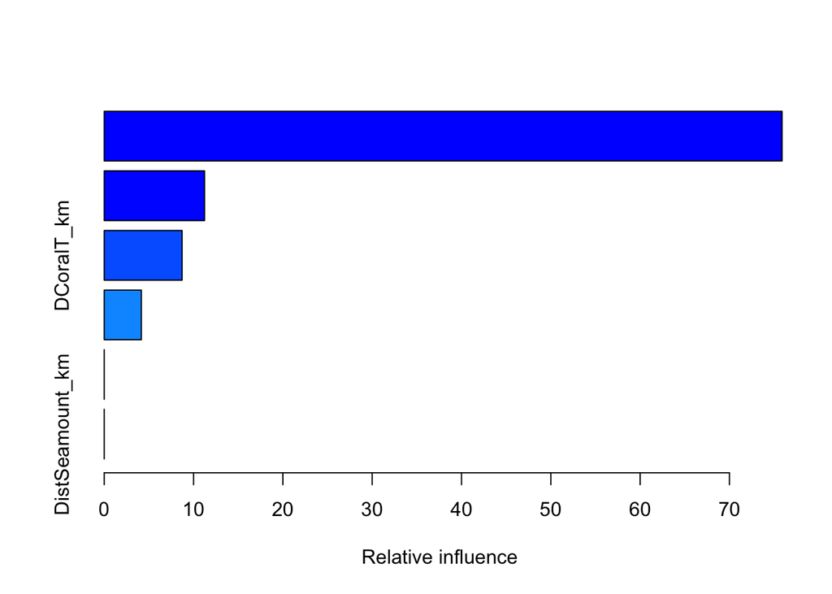

```
##                             var   rel.inf
## SST_median           SST_median 75.892592
## SST_sd                   SST_sd 11.232668
## DCoralT_km           DCoralT_km  8.718522
## Dcoast_km             Dcoast_km  4.156217
## Depth                     Depth  0.000000
## DistSeamount_km DistSeamount_km  0.000000
```

```r
#use species richness as the response variable, including all variables
boost.sp.rich.high.cont.tree <- gbm(formula = SR~+Dcoast_km+DCoralT_km+Depth+SST_median+SST_sd+DistSeamount_km, data = fb, n.trees = 50, shrinkage = 0.01, bag.fraction = 0.5, distribution = "poisson")#using all  predator community attributes found as having highest relative contribution in Figure3A in publication to identify which had the highest relative influence on species richness using the gbm package and parameters specified in the file "brt.parameters.models.specific.predator.attributes.csv"

summary(boost.sp.rich.high.cont.tree)#summary of the results
```

The BRT in re-analysis using only variables found in Figure 3A in the publication was starkly different than Figure 3A in the publication. It is unclear why there is such a stark difference in plot outcome, both with respect to variable contribution as well as scale of contribution, however, it may be due to the fact that variables included in Figure 3A were transformed before usage in BRT analysis.

Then, partial dependence plots were used to identify the relationship between distance to the coast and species richness, as well as the distance to the Coral Triangle and species richness, both with the removal of the influence of other contributing variables. Data for the partial dependence plots were used from the BRT “boost.sp.rich.high.cont.tree”, the BRT with reduced number of variables in an attempt to replicate Figure 3A in the publication.

Partial Dependence Plot (Figure 3B) (Species richness ~ Distance to coast)

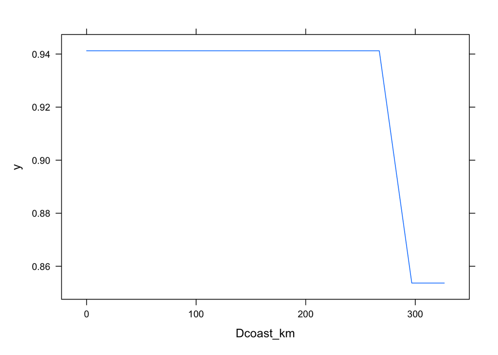

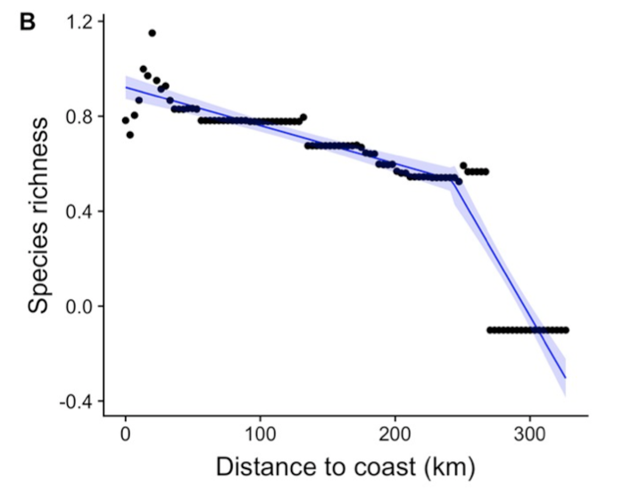

```r
plot.gbm(boost.sp.rich.high.cont.tree,i.var=1, continuous.resolution = 12)#using plot.gbm function in gbm package to generate partial dependence plot, i.var =1 was used because Dcoast_km was first variable in "boost.sp.rich.high.cont.tree", and continuous.resolution of 12 was resulting most closely resembling Figure 3B
```

Overall, the partial dependence plot for identifying the relationship between distance to the coast and species richness were similar in the fact that there is an overall negative trend between species richness and distance to coast, however, there appears to be a plateau from 0-~275 km in the re-analyzed plot. It is unclear exactly whether there were more specifications used to produce the figure in the publication, leading to the observed ifference between the results in these two figures since re-analyzed data was un-transformed and plotted.

Partial Dependence Plot (Figure 3C) (Species richness ~ Distance to Coral Triangle)

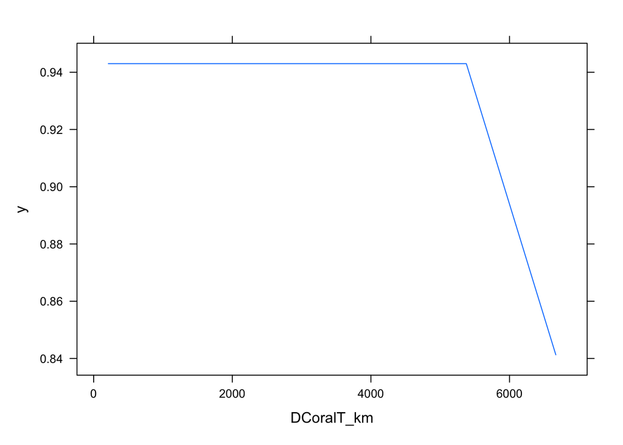

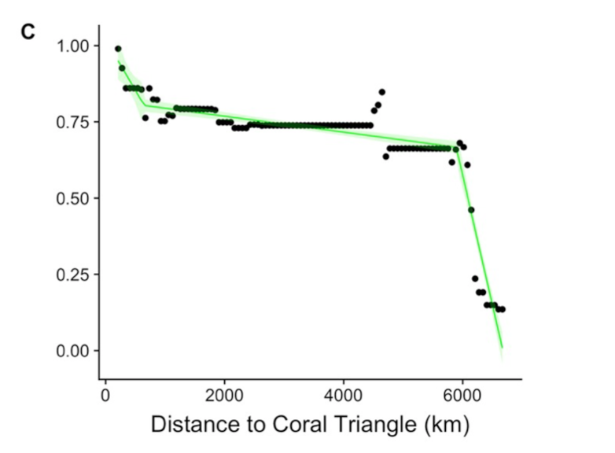

```r
plot.gbm(boost.sp.rich.high.cont.tree,i.var=2, continuous.resolution = 6)#using plot.gbm function in gbm package to generate partial dependence plot, i.var =1 was used because DcoralT_km was second variable in "boost.sp.rich.high.cont.tree", and continuous.resolution of 6 was resulting most closely resembling Figure 3B
```

Overall, the partial dependence plot for identifying the relationship between distance to the Coral Triangle and species richness were similar in the fact that there is an overall negative trend between species richness and distance to coast, however, there appears to be a plateau from 0-~5500 km in the re-analyzed plot. It is unclear exactly whether there were more specifications used to produce the figure in the publication, leading to the observed ifference between the results in these two figures since re-analyzed data was un-transformed and plotted.

Boosted Regression Trees for relative contribution of variables to Body size

Body Size (Figure 4A) (includes all potential variables that may contribute to species richness across sites)

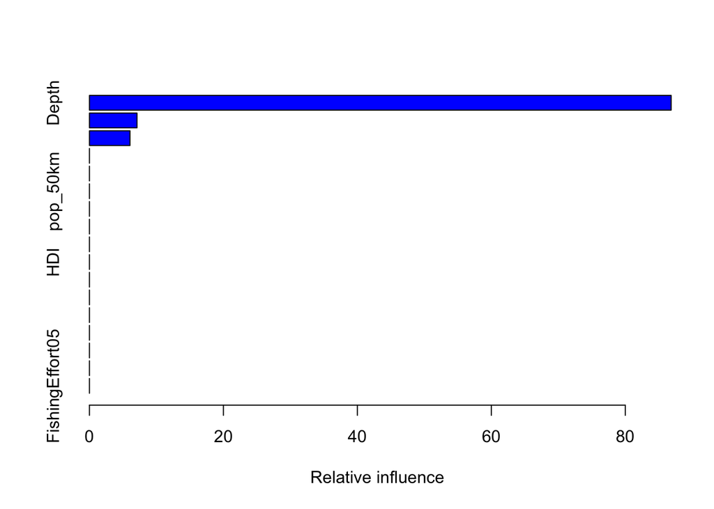

```
##                                     var   rel.inf
## Depth                             Depth 86.853316
## SST_median                   SST_median  7.098095
## SST_sd                           SST_sd  6.048589
## Chla_median                 Chla_median  0.000000
## Chla_sd                         Chla_sd  0.000000
## pop_50km                       pop_50km  0.000000
## pop_500km                     pop_500km  0.000000
## Dist_nearest_pop       Dist_nearest_pop  0.000000
## Dist_nearest_market Dist_nearest_market  0.000000
## HDI                                 HDI  0.000000
## Dcoast_km                     Dcoast_km  0.000000
## DCoralT_km                   DCoralT_km  0.000000
## DistSeamount_km         DistSeamount_km  0.000000
## GDP                                 GDP  0.000000
## Dist_SMT1500               Dist_SMT1500  0.000000
## FishingEffort01         FishingEffort01  0.000000
## FishingEffort05         FishingEffort05  0.000000
```

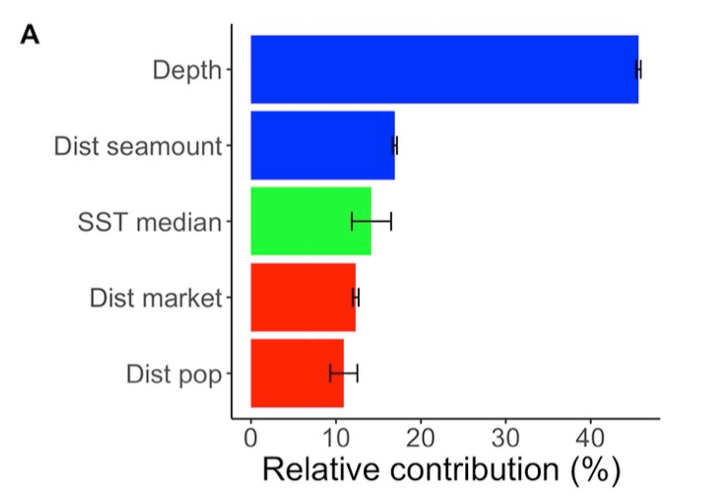

```r
#use species richness as the response variable, including all variables
boost.body.size.tree <- gbm(formula = MaxL~+Depth+Chla_median+Chla_sd+SST_median+SST_sd
                          +pop_50km+pop_500km+Dist_nearest_pop+Dist_nearest_market+HDI+Dcoast_km+DCoralT_km+DistSeamount_km+GDP+Dist_SMT1500+FishingEffort01+FishingEffort05, data = fb, n.trees = 50, shrinkage = 0.01, bag.fraction = 0.5, distribution = "gaussian")
summary(boost.body.size.tree)#using all  predator community attributes catergorized as either 1) geomorphology, 2) environmental conditions, or 3) human pressure to identify which had the highest relative influence on body size using the gbm package and parameters specified in the file "brt.parameters.models.specific.predator.attributes.csv"
```

Body size (using variables found as having highest relative contribution in Figure4A in publication)

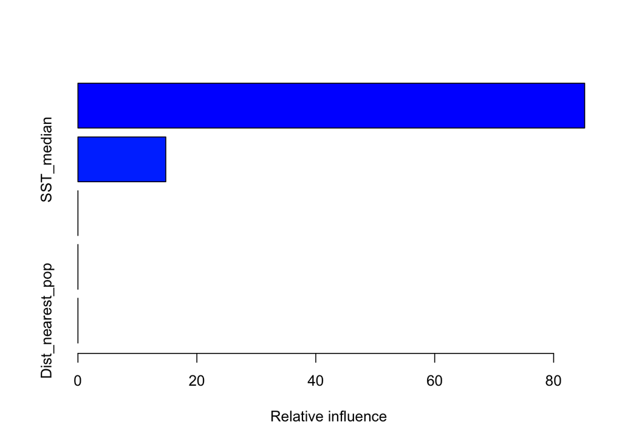

```
##                                     var  rel.inf
## Depth                             Depth 85.21964
## SST_median                   SST_median 14.78036
## DistSeamount_km         DistSeamount_km  0.00000
## Dist_nearest_market Dist_nearest_market  0.00000
## Dist_nearest_pop       Dist_nearest_pop  0.00000
```

```r
boost.body.size.high.cont.tree <- gbm(formula = MaxL~+Depth+DistSeamount_km+SST_median+Dist_nearest_market+Dist_nearest_pop, data = fb, n.trees = 50, shrinkage = 0.01, bag.fraction = 0.5, distribution = "gaussian")#using all  predator community attributes found as having highest relative contribution in Figure4A in publication to identify which had the highest relative influence on species richness using the gbm package and parameters specified in the file "brt.parameters.models.specific.predator.attributes.csv"

summary(boost.body.size.high.cont.tree)#summary of the results
```

Partial Dependence Plot (Figure 4B) (Body size ~ Depth)

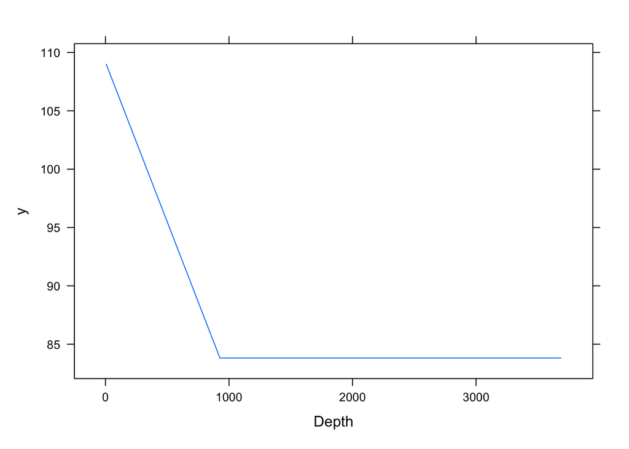

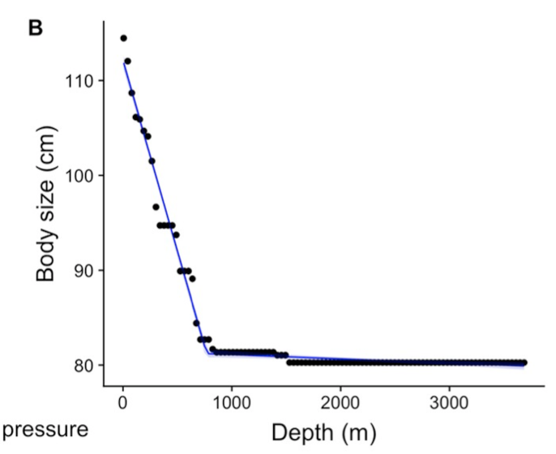

```r
plot.gbm(boost.body.size.high.cont.tree,i.var=1, continuous.resolution = 5)#using plot.gbm function in gbm package to generate partial dependence plot, i.var =1 was used because DcoralT_km was second variable in "boost.sp.rich.high.cont.tree", and continuous.resolution of 6 was resulting most closely resembling Figure 3B
```

Overall, the plot produced in re-analysis was highly similar in scale and the linear relationship shown between depth and body size, however, no data points were plotted in the re-analyzed plot, likely due to missing specifications that were liekly used to produce the plot in the publication.

Partial Dependence Plot (Figure 4C) (Body size ~ Distance to nearest market)

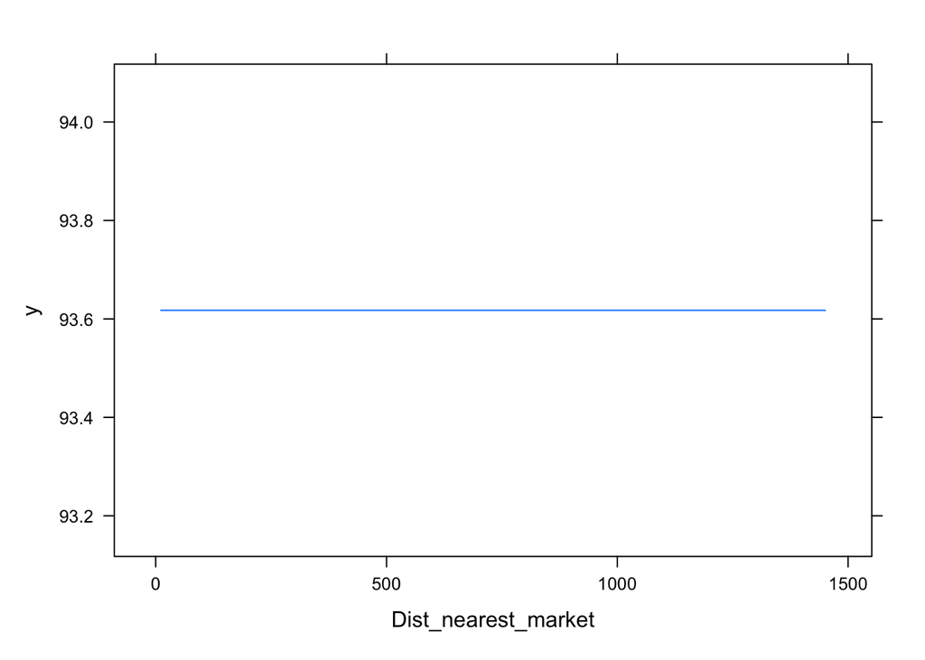

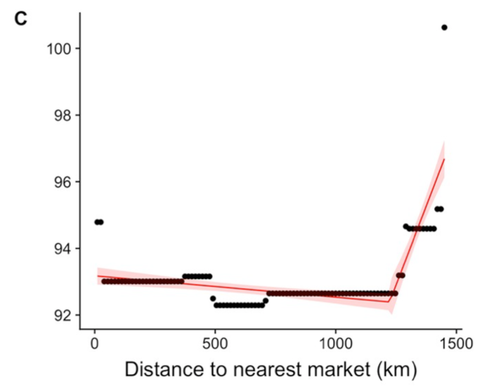

```r
plot.gbm(boost.body.size.high.cont.tree,i.var=4, continuous.resolution = 10)#using plot.gbm function in gbm package to generate partial dependence plot, i.var =1 was used because Dist_nearest_market was fourth variable in "boost.sp.rich.high.cont.tree", and continuous.resolution of 10 was resulting most closely resembling Figure 3B
```

The plot produced in re-analysis was similar in scale to the plot in the publication, however, it is unclear why there is such a stark difference in the plot in re-analysis compared to the plto in the publication.

Now, the number of datapoints in each location was calculated. Compared to the results in the publication (Figure 1A), despite there being 1041 data points in the publication and in the raw data file, there are discrepancies in the exact number of data points in each site, and in the publication, there are 9 locations, whereas in the data file, there are 11. This was likely due to a typo as well as errors in raw data curation.

```r
table(fb['location'])
```

```
##
##   CH  DHI  GAM  MEW  NEW  PAL   PC  RAP RAPB  TIM  TON
##  385   67   45    1  152  135   52   50    2  116   36
```

Now, the densities of species richness and body size were plotted according to different management regimes (as shown in Figure 1A). Shark abundance was not analyzed due to the reasons specified in early shark abundance data analysis.

```r
#Defining different management regimes of deployments in different geographic locations (Figure 6A and 6B) using information from Figure 1A.
unprotected.locations <- c("GAM", "NEW", "PAL", "RAP", "RAPB", "TON")
part.protected.location <- c("TIM", "DHI", "PC")
no.take.mpas <- c("CH")
#Creating new data frame, also called "fb", containing new column called "protection", where management level is specified based on the 3 lines above, using multiple if_else statements.
fb <- fb %>%
  mutate(fb, protection = if_else(location %in% unprotected.locations, "unprotected",
                              if_else(location %in% part.protected.location, "part.protected",
                                      "protected")))
```

Plotting frequency distributions of species richness and body size predicted to occur under different management regimes.

Species Richness frequency distribution (Figure 6A)

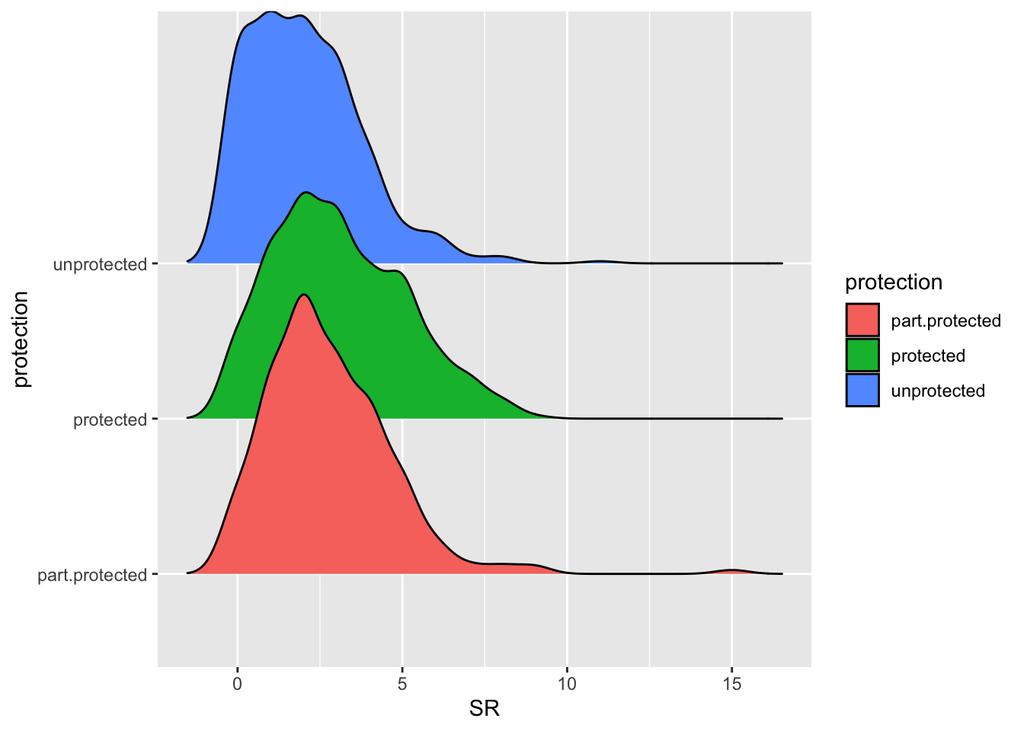

```r
a <- ggplot(fb, aes(x = SR, fill = protection, y = protection,)) + geom_density_ridges()#using ggplot to plot frequency distributions of species richness (x). Y acts similar to facet_wrap, where each curve corresponds to species richness for all locations in one of three specified management regimes, and geom_density_ridges plots the species richness frequency distribution for each management regime.
a
```

Body Size frequency distribution (Figure 6B)

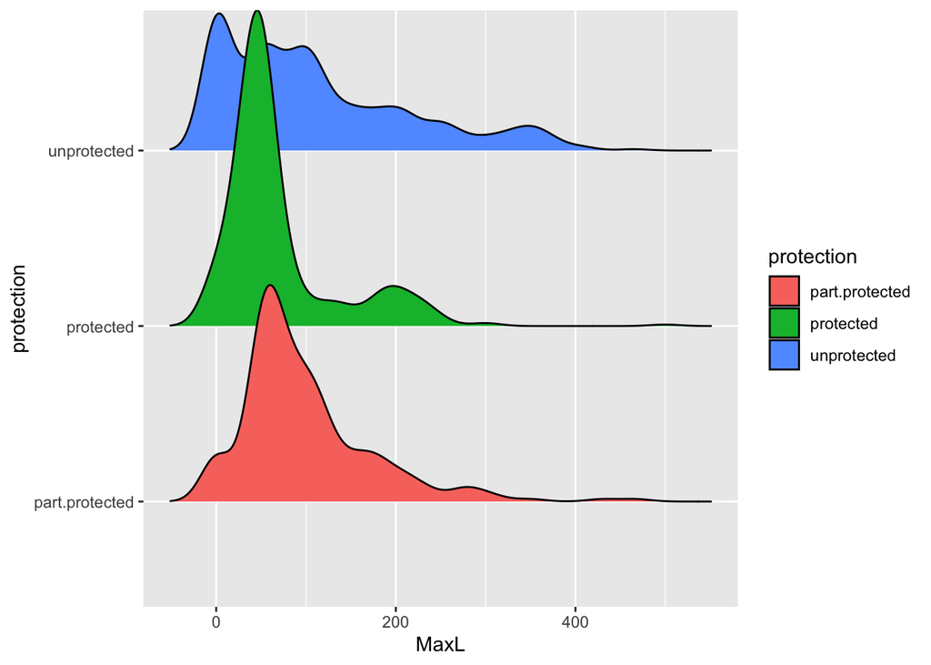

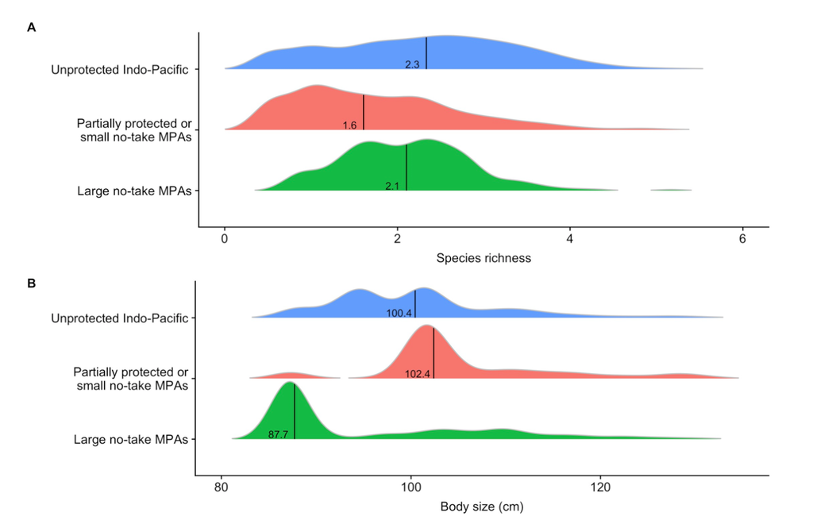

```r
b <- ggplot(fb, aes(x = MaxL, fill = protection, y = protection)) + geom_density_ridges()#using ggplot to plot frequency distributions of body size (x). Y acts similar to facet_wrap, where each curve corresponds to species richness for all locations in one of three specified management regimes, and geom_density_ridges plots the body size frequency distribution for each management regime.
b
```

Discussion and Reflection

On the other hand, re-analysis of the shark abundance frequency distribution plot (Figure 1D) produced a figure starkly different than that presented in the paper. TaSharks, a log-transformed variable attributed to shark abundance, was un-transformed before plotting in the publication. Upon correspondence with the lead author of the publication, it was advised to un-transform TaSharks before plotting shark abundance. There was still a discrepancy in plot outcome, however, even after data un-transformation, and it is unclear whether further data transformation was employed before utilizing shark abundance data for analysis and plotting.

In addition, re-analysis of shark abundance per geographic region (Figure 1E) also produced a starkly different plot than that presented in the publication. This could be due to erroneous un-transformation of TaSharks, however, upon closer inspection, it appeared that there were more geographic locations in the re-analyzed plot than that in the publication (9 in the publication vs. 11 in the raw data file). Upon correspondence with the main author, it appears that there were likely typos in geographic location names, however, there also appeared to be discrepancies between the number of data points (deployments) reported in Figure 1A and in the raw data file “raw.sr.bodysize.sharkabundance.xlsx” for each geographic location, despite 1041 deployments in both Figure 1A and in the raw data file “raw.sr.bodysize.sharkabundance.xlsx”. This may be likely due to errors in raw data curation, and was left unresolved to avoid further confusion. As a result, there were no further analyses including shark abundance.

None of the boosted regression tree re-analyses produced figures marginally close to those presented in the publication. For example, none of the BRTs are similar to those in the publication with respect to percent contribution or identity of predator community attributes to either species richness or body size. The re-analyzed BRTs all report significantly more percent contribution of variables to species richness and body size than the percent contribution reported in the BRTs in the publication, and many of the variables found to contribute significantly to species richness and body size in the publication’s figures had some or almost no contribution to species richness and body size in the re-analysed BRTs. Despite there being a file reporting the parameters used for boosted regression tree analysis “brt.parameters.models.specific.predator.attributes.csv”, there was confusion about the implementation of certain parameters in the model. For example, it was unclear how to implement the maximum number of trees since there was already a parameter included for the number of trees, as well as for implementing tree complexity. In addition, despite being informed by the lead author to implement spatial autocorrelation, it was unclear on how to implement two spatial autocorrelation parameters: spatial autocorrelation in observations and spatial autocorrelation in residuals of final autocovariate model. In addition, it was also unclear about how the authors went about selecting the different predictor variables to assess their relative contribution to species richness and body size. This is likely due to a general unfamiliarity with coding boosted regression trees in R.